**Bar Charts**

```r
#str(shoppers)
```

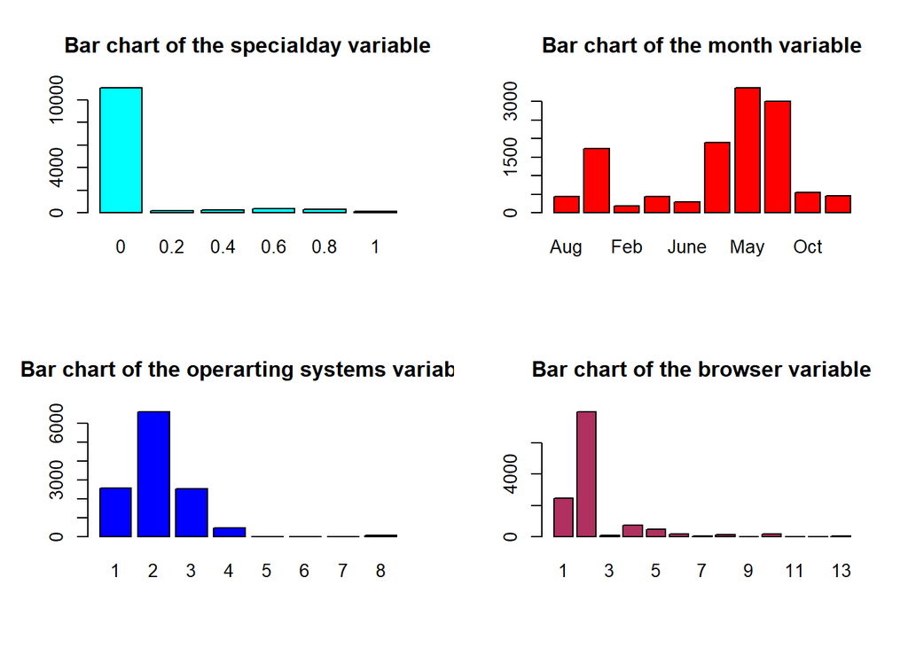

```r
#plotting barcharts of factor variables (specialday, month, operating systems, browser, region, traffictype, weekend and revenue )

day<-shoppers$SpecialDay         #fetching special day column
day_frequency<- table(day)       #creating a frequency table

month<-shoppers$Month           #fetching month column
month_frequency<- table(month)  #creating a frequency table

os<-shoppers$OperatingSystems
os_frequency<- table(os)

browser<-shoppers$Browser
browser_frequency<- table(browser)

region<-shoppers$Region
region_frequency<- table(region)

traffic<-shoppers$TrafficType
traffic_frequency<- table(traffic)

visitor<-shoppers$VisitorType
visitor_frequency<- table(visitor)

weekend<-shoppers$Weekend
weekend_frequency<- table(weekend)

revenue<-shoppers$Revenue
revenue_frequency<- table(revenue)


#plotting bar charts using the frequency tables
par(mfrow=c(2,2))
barplot((day_frequency), col = "cyan", main = "Bar chart of the specialday variable")
barplot((month_frequency), col = "red", main = "Bar chart of the month variable")
barplot((os_frequency), col = "blue", main = "Bar chart of the operarting systems variable")
barplot((browser_frequency), col = "maroon", main = "Bar chart of the browser variable")
```

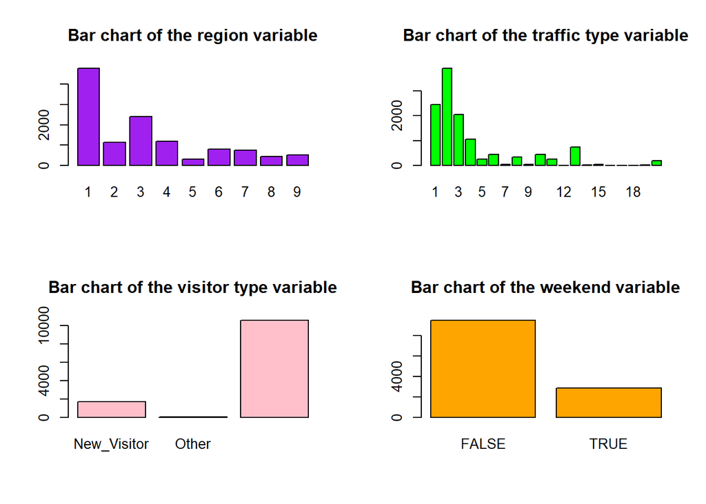

```r
barplot((region_frequency), col = "purple", main = "Bar chart of the region variable")
barplot((traffic_frequency), col = "green", main = "Bar chart of the traffic type variable")
barplot((visitor_frequency), col = "pink", main = "Bar chart of the visitor type variable")
barplot((weekend_frequency), col = "orange", main = "Bar chart of the weekend variable")
```

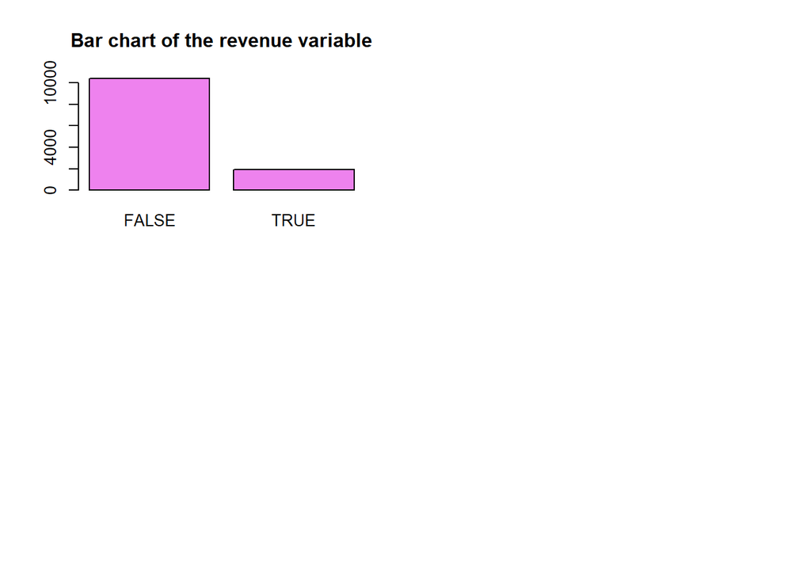

```r
barplot((revenue_frequency), col = "violet", main = "Bar chart of the revenue variable")
```

*Observations*

- Most visitors are using 2 operating systems
- Most visitors are from region one
- Majority of the users are using two browsers
- Majority of the visitors are return visitors
- The Target variable Revenue has more Records of False than True

## 5. Bivariate Analysis

**Correlation**

```r
#creating a dataframe of all the numerical columns

admin <- shoppers$Administrative
admin_duration <- shoppers$Administrative_Duration
info <- shoppers$Informational
info_duration <- shoppers$Informational_Duration
product <- shoppers$ProductRelated
product_duration <- shoppers$ProductRelated_Duration
bounce <- shoppers$BounceRates
exit<- shoppers$ExitRates
pages<- shoppers$ExitRates

numerical <- data.frame(admin, admin_duration, info, info_duration, product, product_duration, bounce, exit, pages)
head(numerical)
```

```
##   admin admin_duration info info_duration product product_duration     bounce
## 1     0              0    0             0       1         0.000000 0.20000000
## 2     0              0    0             0       2        64.000000 0.00000000
## 3     0             -1    0            -1       1        -1.000000 0.20000000
## 4     0              0    0             0       2         2.666667 0.05000000
## 5     0              0    0             0      10       627.500000 0.02000000
## 6     0              0    0             0      19       154.216667 0.01578947
##        exit     pages
## 1 0.2000000 0.2000000
## 2 0.1000000 0.1000000
## 3 0.2000000 0.2000000
## 4 0.1400000 0.1400000
## 5 0.0500000 0.0500000
## 6 0.0245614 0.0245614
```

```r
#calculating a correlation matrix of the dataframe created

corr <- round(cor(numerical), 1) #numerical matrix to 1dp
head(corr[, 1:6])  #previewing the matrix
```

```
##                  admin admin_duration info info_duration product
## admin              1.0            0.6  0.4           0.3     0.4
## admin_duration     0.6            1.0  0.3           0.2     0.3
## info               0.4            0.3  1.0           0.6     0.4
## info_duration      0.3            0.2  0.6           1.0     0.3
## product            0.4            0.3  0.4           0.3     1.0
## product_duration   0.4            0.4  0.4           0.3     0.9
##                  product_duration
## admin                         0.4
## admin_duration                0.4
## info                          0.4
## info_duration                 0.3
## product                       0.9
## product_duration              1.0
```

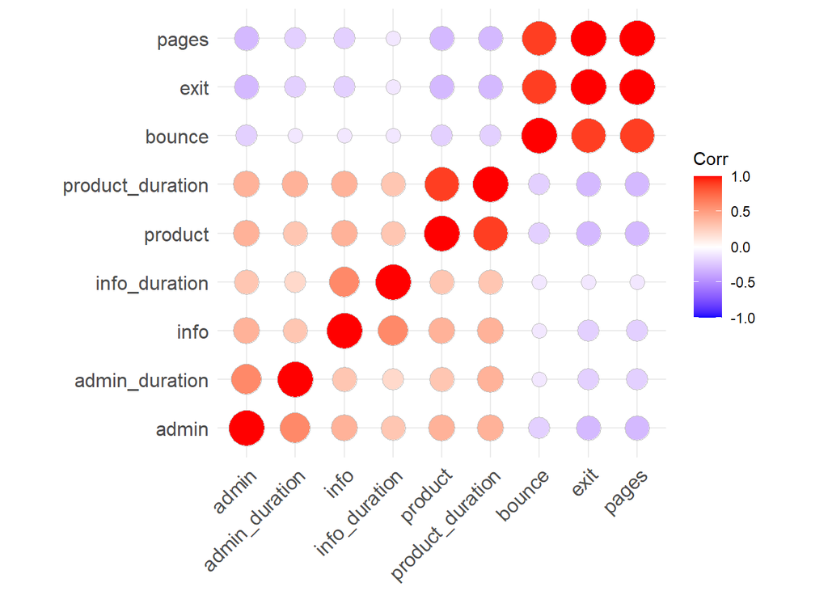

```r
#correlation matrix

library(ggcorrplot)
ggcorrplot(corr, method = "circle")
```

```r
#str(shoppers)
```

**Box plots**

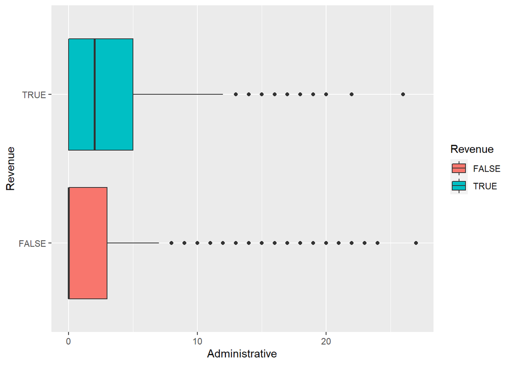

```r
#how do all the variables relate with the revenue


#plotting boxplots to show how the Administrative page relates with the revenue
ggplot(data = shoppers, mapping = aes(x = Revenue, y = Administrative, fill = Revenue)) +
  geom_boxplot() +
  coord_flip()
```

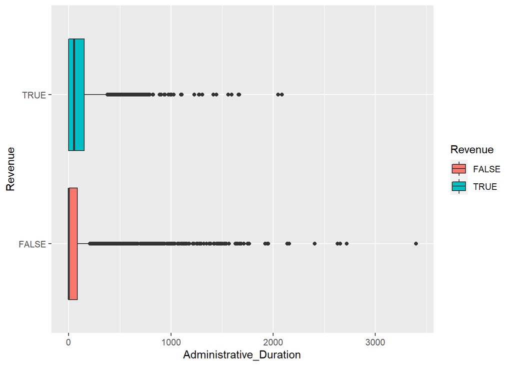

```r
#plotting boxplots to show how the duration spent on administrative pages relates with the revenue
ggplot(data = shoppers, mapping = aes(x = Revenue, y = Administrative_Duration, fill = Revenue)) +
  geom_boxplot() +
  coord_flip()
```

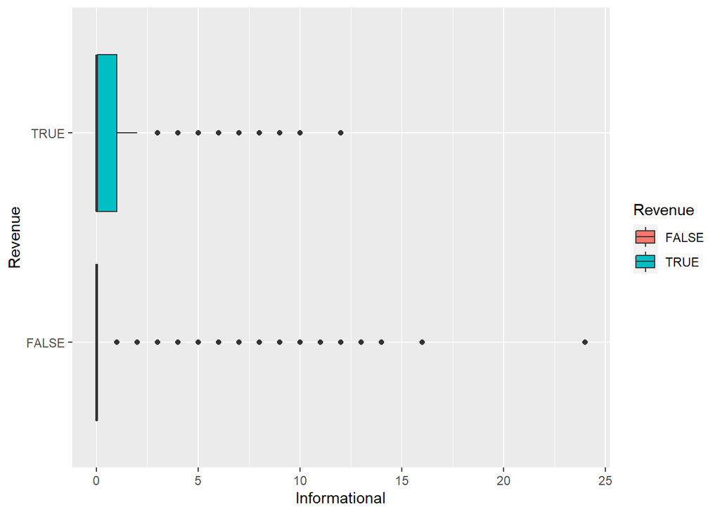

```r
#plotting boxplots to show how the informational pages relate with the revenue
ggplot(data = shoppers, mapping = aes(x = Revenue, y = Informational, fill = Revenue)) +
  geom_boxplot() +
  coord_flip()
```

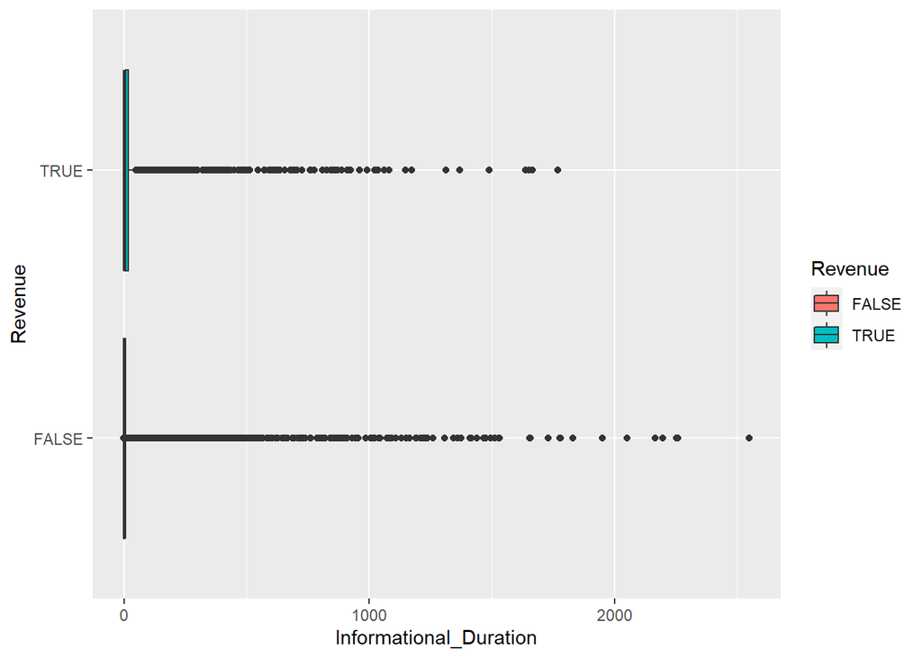

```r
#plotting boxplots to show how the duration spent on the informational pages relates with the revenue
ggplot(data = shoppers, mapping = aes(x = Revenue, y = Informational_Duration, fill = Revenue)) +
  geom_boxplot() +
  coord_flip()
```

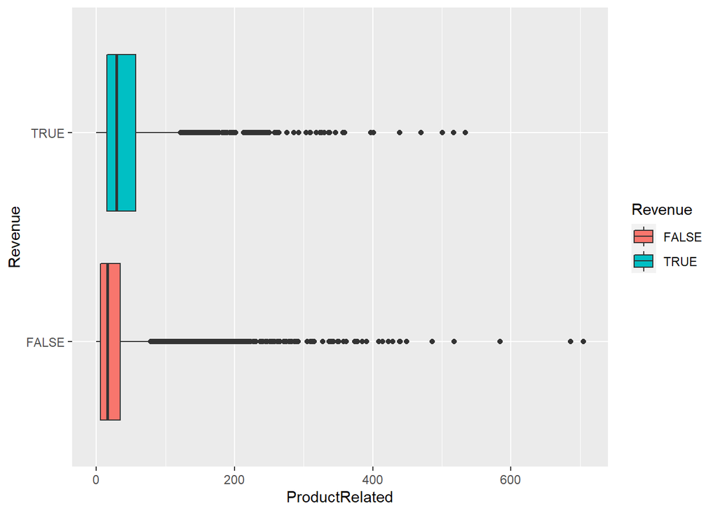

```r
#plotting boxplots to show how the product related pages relates with the revenue
ggplot(data = shoppers, mapping = aes(x = Revenue, y = ProductRelated, fill = Revenue)) +
  geom_boxplot() +
  coord_flip()
```

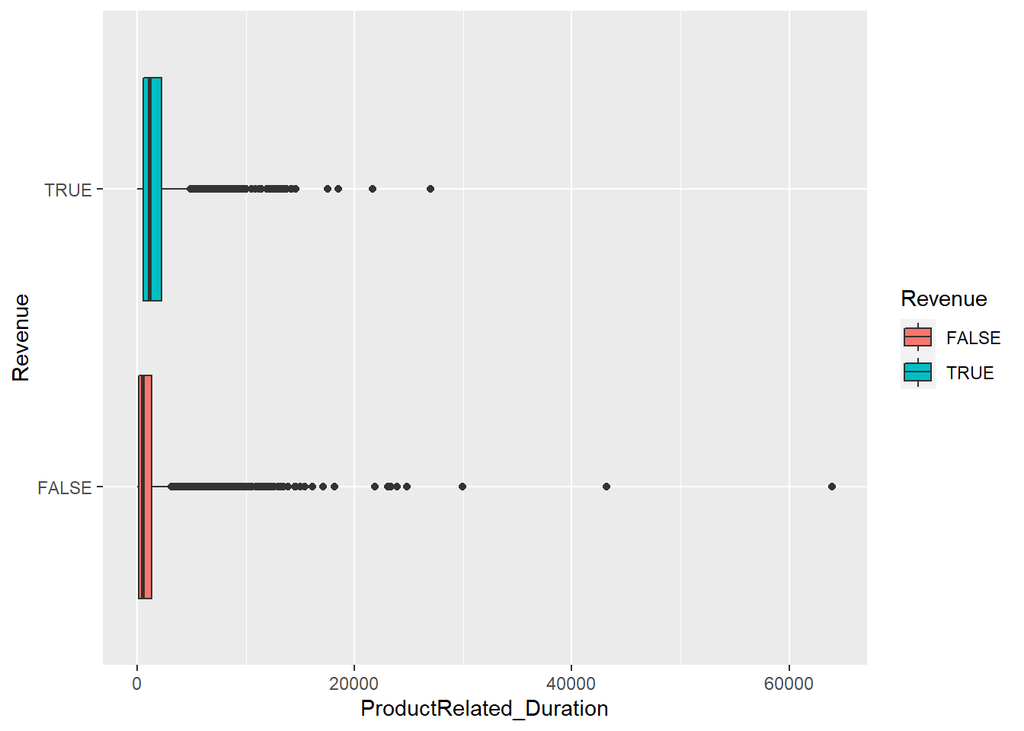

```r
#plotting boxplots to show how the duration spent on the product related pages relates with the revenue
ggplot(data = shoppers, mapping = aes(x = Revenue, y = ProductRelated_Duration, fill = Revenue)) +
  geom_boxplot() +
  coord_flip()
```

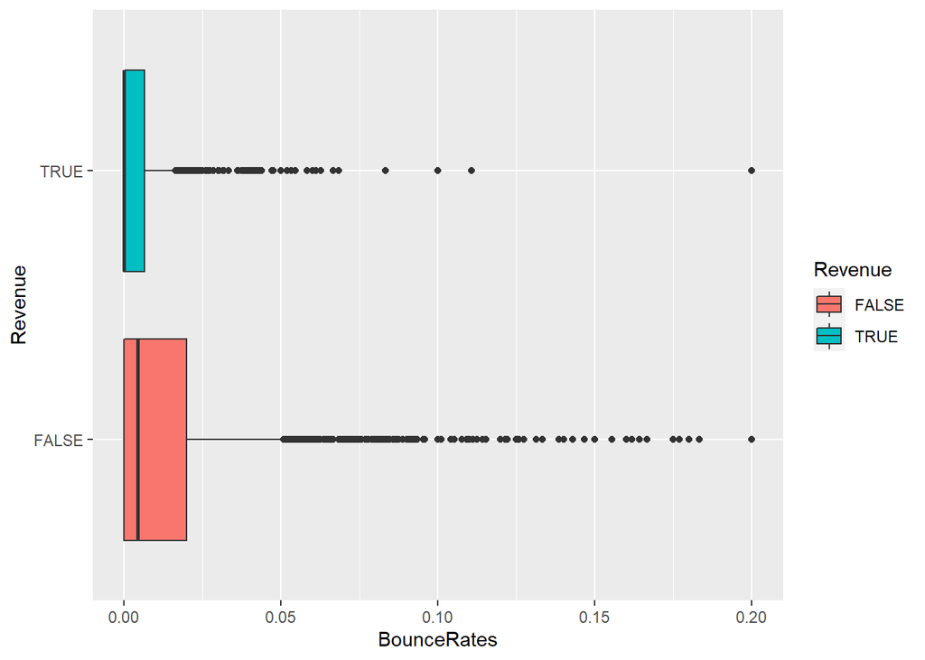

```r
#plotting boxplots to show how the bouncerates influence the revenue
ggplot(data = shoppers, mapping = aes(x = Revenue, y = BounceRates, fill = Revenue)) +
  geom_boxplot() +
  coord_flip()
```

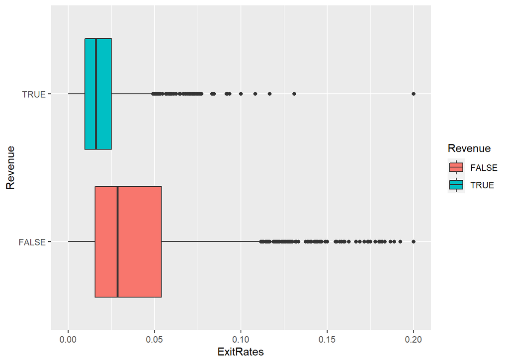

```r
#plotting boxplots to show how the exitrates influence the revenue
ggplot(data = shoppers, mapping = aes(x = Revenue, y = ExitRates, fill = Revenue)) +
  geom_boxplot() +
  coord_flip()
```

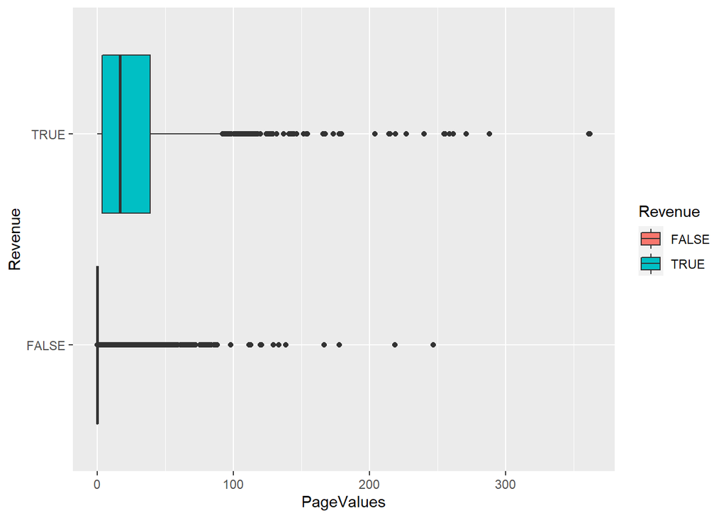

```r
#plotting boxplots to show how the pagevalues influence the revenue
ggplot(data = shoppers, mapping = aes(x = Revenue, y = PageValues, fill = Revenue)) +
  geom_boxplot() +
  coord_flip()
```

*The Administrative, Informational and Product related pages bring in more more revenue* The duration spent on all the three pages bring in more revenue, however, the administrative pages bring in more revenue as compared to the informational and product related pages *Bouncerates and exit rates bring in less revenue* Page values bring in the most revenue

**Barplots**

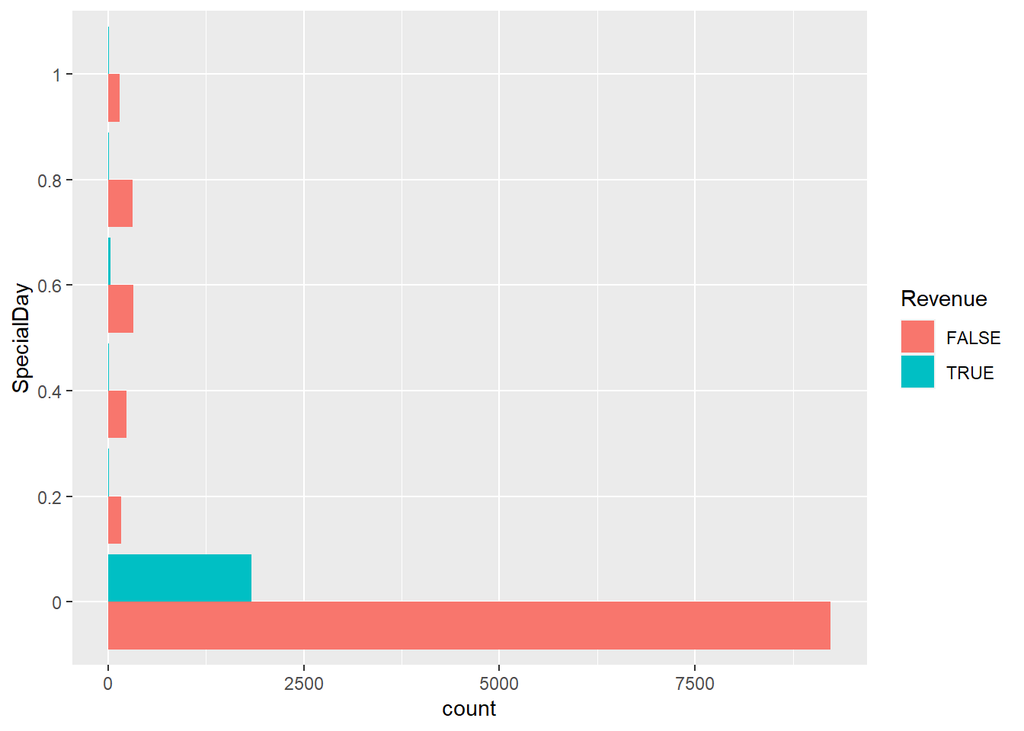

```r
#barplot showing how much revenue is generated on different special days
ggplot(data = shoppers) +
  geom_bar(mapping = aes(x = SpecialDay, fill = Revenue), position = "dodge")+
  coord_flip()
```

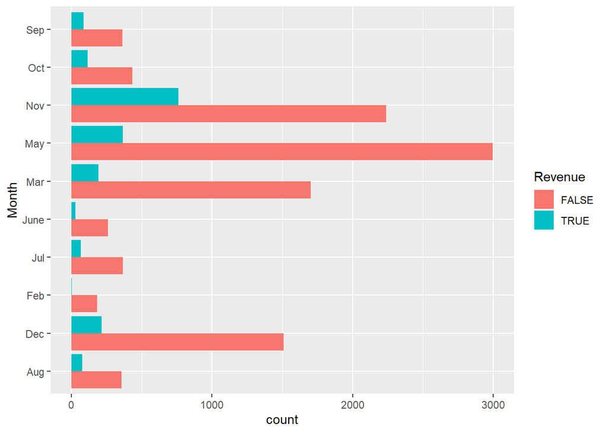

```r
#barplot showing how much revenue is generated each month
ggplot(data = shoppers) +
  geom_bar(mapping = aes(x = Month, fill = Revenue), position = "dodge")+
  coord_flip()
```

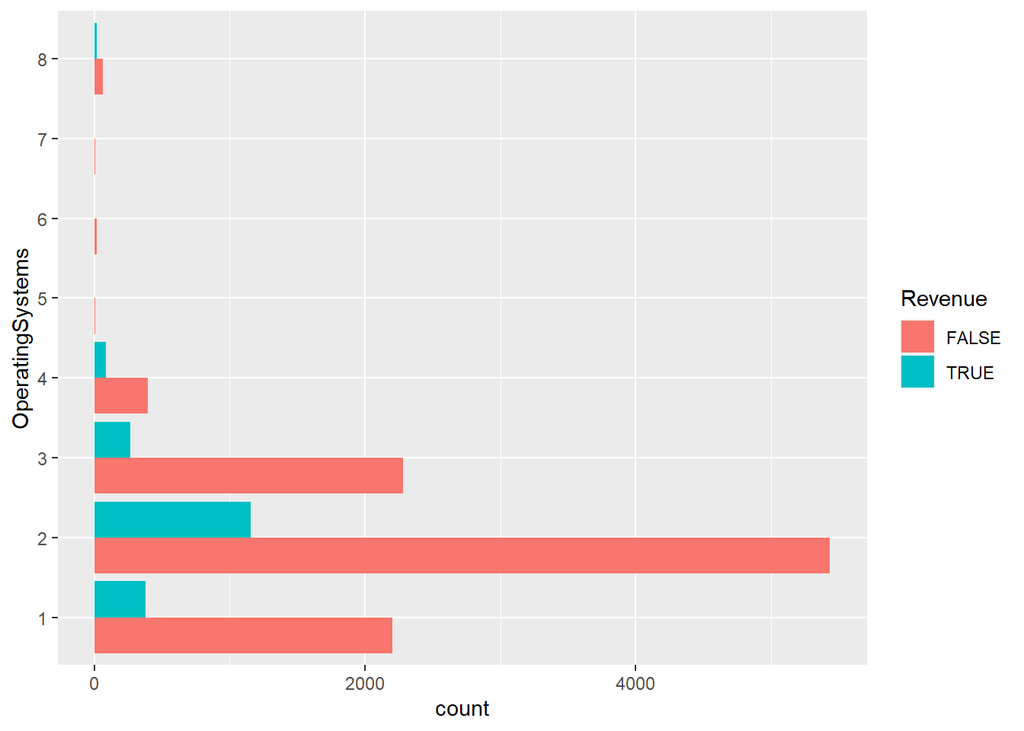

```r
#barplot showing how much revenue is generated from different operating systems
ggplot(data = shoppers) +
  geom_bar(mapping = aes(x = OperatingSystems, fill = Revenue), position = "dodge")+
  coord_flip()
```

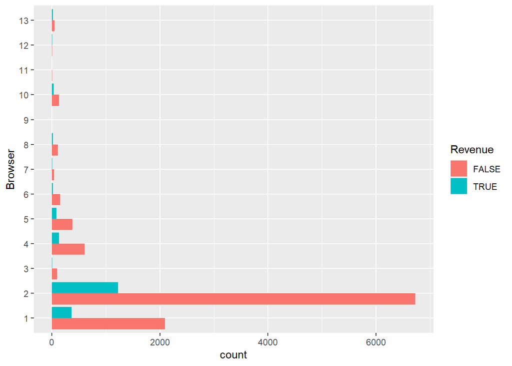

```r
#barplot showing how much revenue is generated from different browsers
ggplot(data = shoppers) +
  geom_bar(mapping = aes(x =Browser, fill = Revenue), position = "dodge")+
  coord_flip()
```